# Topic 3.1: Probabilistic Learning and k-NN

Simple examples + Case Study: Failure Case Study

Advanced Modelling, Master in Computational Social Science

UC3M, 2026

# 1 Introduction

In this notebook we will practice with the tools seen in topic 3.1, where we introduced supervised learning and focused on probabilistic learning model based on Bayes rule (LDA, QDA, Naive Bayes) as well as k-Nearest Neighbors.

We will start with a few “toy” examples and then we will try to apply some of these techniques in a real case study about student failure prediction using socioeconomic variables.

```r
# Required packages
library(tidyverse)
library(caret)
library(MASS)
library(e1071)
library(class)
```

# 2 Multiclass Classification Example (Iris)

In this first example we use a well known example dataset, which consists of 3 flower species (the three classes we will try to predict, the response Y), where 4 variables have been measured, with the sepal and petal widths and lenghts (the X matrix that we will use to predict). For more information read [the Wikipedia page](https://es.wikipedia.org/wiki/Conjunto_de_datos_flor_iris).

Lets have a look to our data:

```r
data(iris)
glimpse(iris)
```

```
## Rows: 150
## Columns: 5
## $ Sepal.Length <dbl> 5.1, 4.9, 4.7, 4.6, 5.0, 5.4, 4.6, 5.0, 4.4, 4.9, 5.4, 4.…
## $ Sepal.Width  <dbl> 3.5, 3.0, 3.2, 3.1, 3.6, 3.9, 3.4, 3.4, 2.9, 3.1, 3.7, 3.…
## $ Petal.Length <dbl> 1.4, 1.4, 1.3, 1.5, 1.4, 1.7, 1.4, 1.5, 1.4, 1.5, 1.5, 1.…
## $ Petal.Width  <dbl> 0.2, 0.2, 0.2, 0.2, 0.2, 0.4, 0.3, 0.2, 0.2, 0.1, 0.2, 0.…
## $ Species      <fct> setosa, setosa, setosa, setosa, setosa, setosa, setosa, s…
```

```r
summary(iris)
```

```
##   Sepal.Length    Sepal.Width     Petal.Length    Petal.Width
##  Min.   :4.300   Min.   :2.000   Min.   :1.000   Min.   :0.100
##  1st Qu.:5.100   1st Qu.:2.800   1st Qu.:1.600   1st Qu.:0.300
##  Median :5.800   Median :3.000   Median :4.350   Median :1.300
##  Mean   :5.843   Mean   :3.057   Mean   :3.758   Mean   :1.199
##  3rd Qu.:6.400   3rd Qu.:3.300   3rd Qu.:5.100   3rd Qu.:1.800
##  Max.   :7.900   Max.   :4.400   Max.   :6.900   Max.   :2.500
##        Species
##  setosa    :50
##  versicolor:50
##  virginica :50
##
##
##
```

Before creating any model, we knwo that we should first have some validation strategy. Lets start by using a simple train/test split for simplicity in this example, even if a cross validation approach would be more robust.

```r
set.seed(123)
iris_idx <- createDataPartition(iris$Species, p = 0.7, list = FALSE)
iris_train <- iris[iris_idx, ]
iris_test <- iris[-iris_idx, ]

cat("Training set:", nrow(iris_train), "observations\n")
```

```
## Training set: 105 observations
```

```r
cat("Test set:", nrow(iris_test), "observations\n")
```

```
## Test set: 45 observations
```

We will now use the three classifier models from Bayesian learning (LDA, QDA and Naive Bayes) and the ML model k-NN as seen in topic 3.1.

For k-NN, we need to scale the data. In general its best practice to do so using training statistics and apply the same scaling to the test set, to avoid data-leakage.

> Note how we are specifying the package where we can get each of the models´

```r
# LDA
iris_lda <- MASS::lda(Species ~ ., data = iris_train)
iris_lda_pred <- predict(iris_lda, newdata = iris_test)$class

# QDA
iris_qda <- MASS::qda(Species ~ ., data = iris_train)
iris_qda_pred <- predict(iris_qda, newdata = iris_test)$class

# Naive Bayes
iris_nb <- e1071::naiveBayes(Species ~ ., data = iris_train)
iris_nb_pred <- predict(iris_nb, newdata = iris_test)

# k-NN: Scaling + model predictions (remember how this model does not require
# training, as it only requires the data to be stored)
train_scaled <- scale(iris_train[, 1:4])
test_scaled <- scale(
  iris_test[, 1:4],
  center = attr(train_scaled, "scaled:center"),
  scale = attr(train_scaled, "scaled:scale")
)

# k-NN predictions for different k values
iris_knn_pred_k1 <- class::knn(
  train = train_scaled,
  test = test_scaled,
  cl = iris_train$Species,
  k = 1
)

iris_knn_pred_k5 <- class::knn(
  train = train_scaled,
  test = test_scaled,
  cl = iris_train$Species,
  k = 5
)

iris_knn_pred_k20 <- class::knn(
  train = train_scaled,
  test = test_scaled,
  cl = iris_train$Species,
  k = 20
)
```

Use the training data’s mean and standard deviation to scale the train data AND the test data. Do not include test data, otherwise you will result with data leakage.

When dealing with classification problems, recall from the topic 1 introduction that we can use the confusion matrix to represent our results as well as metrics such as the accuracy or others related with the false positives or false negatives.

We want to look at accuracy here. When we care more about false positives and false negatives, we might look at other metrics.

```r
cm_iris_lda <- confusionMatrix(iris_lda_pred, iris_test$Species)
cm_iris_qda <- confusionMatrix(iris_qda_pred, iris_test$Species)
cm_iris_nb <- confusionMatrix(iris_nb_pred, iris_test$Species)
cm_iris_knn_k1 <- confusionMatrix(iris_knn_pred_k1, iris_test$Species)
cm_iris_knn_k5 <- confusionMatrix(iris_knn_pred_k5, iris_test$Species)
cm_iris_knn_k20 <- confusionMatrix(iris_knn_pred_k20, iris_test$Species)

cm_iris_lda
```

```
## Confusion Matrix and Statistics
##
##             Reference
## Prediction   setosa versicolor virginica
##   setosa         15          0         0
##   versicolor      0         15         1
##   virginica       0          0        14
##
## Overall Statistics
##
##                Accuracy : 0.9778
##                  95% CI : (0.8823, 0.9994)
##     No Information Rate : 0.3333
##     P-Value [Acc > NIR] : < 2.2e-16
##
##                   Kappa : 0.9667
##
##  Mcnemar's Test P-Value : NA
##
## Statistics by Class:
##
##                      Class: setosa Class: versicolor Class: virginica
## Sensitivity                 1.0000            1.0000           0.9333
## Specificity                 1.0000            0.9667           1.0000
## Pos Pred Value              1.0000            0.9375           1.0000
## Neg Pred Value              1.0000            1.0000           0.9677
## Prevalence                  0.3333            0.3333           0.3333
## Detection Rate              0.3333            0.3333           0.3111
## Detection Prevalence        0.3333            0.3556           0.3111
## Balanced Accuracy           1.0000            0.9833           0.9667
```

```r
cm_iris_qda
```

```
## Confusion Matrix and Statistics
##
##             Reference
## Prediction   setosa versicolor virginica
##   setosa         15          0         0
##   versicolor      0         15         1
##   virginica       0          0        14
##
## Overall Statistics
##
##                Accuracy : 0.9778
##                  95% CI : (0.8823, 0.9994)
##     No Information Rate : 0.3333
##     P-Value [Acc > NIR] : < 2.2e-16
##
##                   Kappa : 0.9667
##
##  Mcnemar's Test P-Value : NA
##
## Statistics by Class:
##
##                      Class: setosa Class: versicolor Class: virginica
## Sensitivity                 1.0000            1.0000           0.9333
## Specificity                 1.0000            0.9667           1.0000
## Pos Pred Value              1.0000            0.9375           1.0000
## Neg Pred Value              1.0000            1.0000           0.9677
## Prevalence                  0.3333            0.3333           0.3333
## Detection Rate              0.3333            0.3333           0.3111
## Detection Prevalence        0.3333            0.3556           0.3111
## Balanced Accuracy           1.0000            0.9833           0.9667
```

```r
cm_iris_nb
```

```
## Confusion Matrix and Statistics
##
##             Reference
## Prediction   setosa versicolor virginica
##   setosa         15          0         0
##   versicolor      0         13         2
##   virginica       0          2        13
##
## Overall Statistics
##
##                Accuracy : 0.9111
##                  95% CI : (0.7878, 0.9752)
##     No Information Rate : 0.3333
##     P-Value [Acc > NIR] : 8.467e-16
##
##                   Kappa : 0.8667
##
##  Mcnemar's Test P-Value : NA
##
## Statistics by Class:
##
##                      Class: setosa Class: versicolor Class: virginica
## Sensitivity                 1.0000            0.8667           0.8667
## Specificity                 1.0000            0.9333           0.9333
## Pos Pred Value              1.0000            0.8667           0.8667
## Neg Pred Value              1.0000            0.9333           0.9333
## Prevalence                  0.3333            0.3333           0.3333
## Detection Rate              0.3333            0.2889           0.2889
## Detection Prevalence        0.3333            0.3333           0.3333
## Balanced Accuracy           1.0000            0.9000           0.9000
```

```r
cm_iris_knn_k1
```

```
## Confusion Matrix and Statistics
##
##             Reference
## Prediction   setosa versicolor virginica
##   setosa         15          0         0
##   versicolor      0         14         3
##   virginica       0          1        12
##
## Overall Statistics
##
##                Accuracy : 0.9111
##                  95% CI : (0.7878, 0.9752)
##     No Information Rate : 0.3333
##     P-Value [Acc > NIR] : 8.467e-16
##
##                   Kappa : 0.8667
##
##  Mcnemar's Test P-Value : NA
##
## Statistics by Class:
##
##                      Class: setosa Class: versicolor Class: virginica
## Sensitivity                 1.0000            0.9333           0.8000
## Specificity                 1.0000            0.9000           0.9667
## Pos Pred Value              1.0000            0.8235           0.9231
## Neg Pred Value              1.0000            0.9643           0.9062
## Prevalence                  0.3333            0.3333           0.3333
## Detection Rate              0.3333            0.3111           0.2667
## Detection Prevalence        0.3333            0.3778           0.2889
## Balanced Accuracy           1.0000            0.9167           0.8833
```

```r
cm_iris_knn_k5
```

```
## Confusion Matrix and Statistics
##
##             Reference
## Prediction   setosa versicolor virginica
##   setosa         15          0         0
##   versicolor      0         14         2
##   virginica       0          1        13
##
## Overall Statistics
##
##                Accuracy : 0.9333
##                  95% CI : (0.8173, 0.986)
##     No Information Rate : 0.3333
##     P-Value [Acc > NIR] : < 2.2e-16
##
##                   Kappa : 0.9
##
##  Mcnemar's Test P-Value : NA
##
## Statistics by Class:
##
##                      Class: setosa Class: versicolor Class: virginica
## Sensitivity                 1.0000            0.9333           0.8667
## Specificity                 1.0000            0.9333           0.9667
## Pos Pred Value              1.0000            0.8750           0.9286
## Neg Pred Value              1.0000            0.9655           0.9355
## Prevalence                  0.3333            0.3333           0.3333
## Detection Rate              0.3333            0.3111           0.2889
## Detection Prevalence        0.3333            0.3556           0.3111
## Balanced Accuracy           1.0000            0.9333           0.9167
```

```r
cm_iris_knn_k20
```

```
## Confusion Matrix and Statistics
##
##             Reference
## Prediction   setosa versicolor virginica
##   setosa         15          0         0
##   versicolor      0         13         3
##   virginica       0          2        12
##
## Overall Statistics
##
##                Accuracy : 0.8889
##                  95% CI : (0.7595, 0.9629)
##     No Information Rate : 0.3333
##     P-Value [Acc > NIR] : 1.408e-14
##
##                   Kappa : 0.8333
##
##  Mcnemar's Test P-Value : NA
##
## Statistics by Class:
##
##                      Class: setosa Class: versicolor Class: virginica
## Sensitivity                 1.0000            0.8667           0.8000
## Specificity                 1.0000            0.9000           0.9333
## Pos Pred Value              1.0000            0.8125           0.8571
## Neg Pred Value              1.0000            0.9310           0.9032
## Prevalence                  0.3333            0.3333           0.3333
## Detection Rate              0.3333            0.2889           0.2667
## Detection Prevalence        0.3333            0.3556           0.3111
## Balanced Accuracy           1.0000            0.8833           0.8667
```

And we can create a summary table:

```r
iris_summary <- tibble(
  Method = c("LDA", "QDA", "Naive Bayes", "k-NN (k=1)", "k-NN (k=5)", "k-NN (k=20)"),
  Accuracy = c(
    as.numeric(cm_iris_lda$overall["Accuracy"]),
    as.numeric(cm_iris_qda$overall["Accuracy"]),
    as.numeric(cm_iris_nb$overall["Accuracy"]),
    as.numeric(cm_iris_knn_k1$overall["Accuracy"]),
    as.numeric(cm_iris_knn_k5$overall["Accuracy"]),
    as.numeric(cm_iris_knn_k20$overall["Accuracy"])
  )
)

knitr::kable(iris_summary, digits = 3)
```

| Method | Accuracy |
| --- | --- |
| LDA | 0.978 |
| QDA | 0.978 |
| Naive Bayes | 0.911 |
| k-NN (k=1) | 0.911 |
| k-NN (k=5) | 0.933 |
| k-NN (k=20) | 0.889 |

When dealing with classification problems, we can try to visualize the decision boundaries of each of our models by plotting our data space (or just a 2D version of it with PCA or selecting two variables) and assigning a color to each point in the space depending on the class that would be predicted to it.

In our case we use only two predictors in the plot: `Petal.Length` and `Petal.Width`.

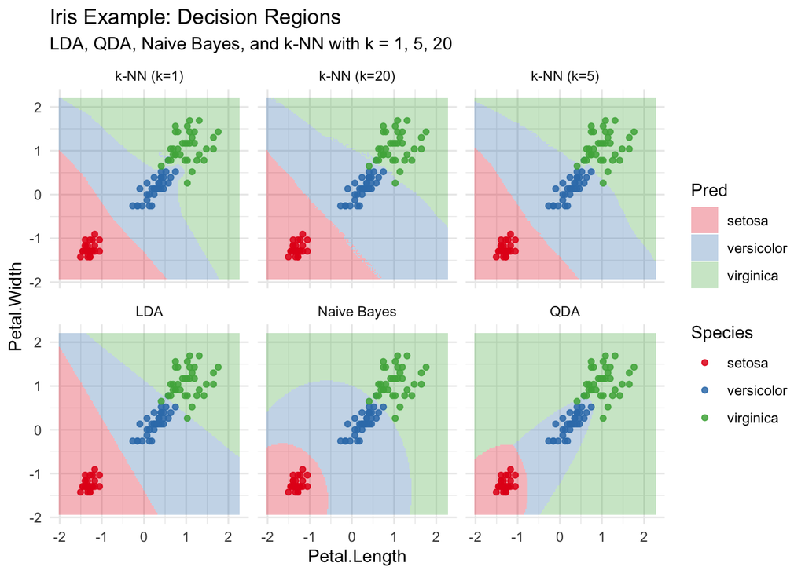

```r
# Two-feature training data
train_2d <- iris_train %>% dplyr::select(Petal.Length, Petal.Width, Species)

# Scale 2D features with train statistics
train_2d_scaled <- scale(train_2d[, c("Petal.Length", "Petal.Width")])
train_2d_df <- data.frame(train_2d_scaled, Species = train_2d$Species)

# Fit models on scaled 2D features
lda_2d <- lda(Species ~ ., data = train_2d_df)
qda_2d <- qda(Species ~ ., data = train_2d_df)
nb_2d <- naiveBayes(Species ~ ., data = train_2d_df)

# Prediction grid
x_range <- seq(min(train_2d_df$Petal.Length) - 0.5, max(train_2d_df$Petal.Length) + 0.5, length.out = 150)
y_range <- seq(min(train_2d_df$Petal.Width) - 0.5, max(train_2d_df$Petal.Width) + 0.5, length.out = 150)
grid <- expand.grid(Petal.Length = x_range, Petal.Width = y_range)

# LDA
grid_lda <- grid
grid_lda$Pred <- predict(lda_2d, newdata = grid)$class
grid_lda$Method <- "LDA"

# QDA
grid_qda <- grid
grid_qda$Pred <- predict(qda_2d, newdata = grid)$class
grid_qda$Method <- "QDA"

# Naive Bayes
grid_nb <- grid
grid_nb$Pred <- predict(nb_2d, newdata = grid)
grid_nb$Method <- "Naive Bayes"

# k-NN (k=1)
grid_knn_k1 <- grid
grid_knn_k1$Pred <- class::knn(
  train = as.matrix(train_2d_df[, c("Petal.Length", "Petal.Width")]),
  test = as.matrix(grid),
  cl = train_2d_df$Species,
  k = 1
)
grid_knn_k1$Method <- "k-NN (k=1)"

# k-NN (k=5)
grid_knn_k5 <- grid
grid_knn_k5$Pred <- class::knn(
  train = as.matrix(train_2d_df[, c("Petal.Length", "Petal.Width")]),
  test = as.matrix(grid),
  cl = train_2d_df$Species,
  k = 5
)
grid_knn_k5$Method <- "k-NN (k=5)"

# k-NN (k=20)
grid_knn_k20 <- grid
grid_knn_k20$Pred <- class::knn(
  train = as.matrix(train_2d_df[, c("Petal.Length", "Petal.Width")]),
  test = as.matrix(grid),
  cl = train_2d_df$Species,
  k = 20
)
grid_knn_k20$Method <- "k-NN (k=20)"

boundary_data <- bind_rows(
  grid_lda, grid_qda, grid_nb,
  grid_knn_k1, grid_knn_k5, grid_knn_k20
)

ggplot() +
  geom_tile(
    data = boundary_data,
    aes(x = Petal.Length, y = Petal.Width, fill = Pred),
    alpha = 0.30
  ) +
  geom_point(
    data = train_2d_df,
    aes(x = Petal.Length, y = Petal.Width, color = Species),
    size = 1.4,
    alpha = 0.85
  ) +
  facet_wrap(~ Method, ncol = 3) +
  labs(
    title = "Iris Example: Decision Regions",
    subtitle = "LDA, QDA, Naive Bayes, and k-NN with k = 1, 5, 20"
  ) +
  theme_minimal() +
  scale_fill_brewer(palette = "Set1") +
  scale_color_brewer(palette = "Set1")
```

# 3 k-NN Regression Example

We have seen a classification example, but this type of model can also be extended to regression problems, where we predict a **continuous target**.

To do so, we will use the `mtcars` example dataset, which contains information about several car models and brands. For visualization purposes we will try to predict the miles per gallon `mpg` variable using their weight `wt` as predictor.

Lets first see the data and create a train and test split with `caret`.

```r
data(mtcars)
glimpse(mtcars)
```

```
## Rows: 32
## Columns: 11
## $ mpg  <dbl> 21.0, 21.0, 22.8, 21.4, 18.7, 18.1, 14.3, 24.4, 22.8, 19.2, 17.8,…
## $ cyl  <dbl> 6, 6, 4, 6, 8, 6, 8, 4, 4, 6, 6, 8, 8, 8, 8, 8, 8, 4, 4, 4, 4, 8,…
## $ disp <dbl> 160.0, 160.0, 108.0, 258.0, 360.0, 225.0, 360.0, 146.7, 140.8, 16…
## $ hp   <dbl> 110, 110, 93, 110, 175, 105, 245, 62, 95, 123, 123, 180, 180, 180…
## $ drat <dbl> 3.90, 3.90, 3.85, 3.08, 3.15, 2.76, 3.21, 3.69, 3.92, 3.92, 3.92,…
## $ wt   <dbl> 2.620, 2.875, 2.320, 3.215, 3.440, 3.460, 3.570, 3.190, 3.150, 3.…
## $ qsec <dbl> 16.46, 17.02, 18.61, 19.44, 17.02, 20.22, 15.84, 20.00, 22.90, 18…
## $ vs   <dbl> 0, 0, 1, 1, 0, 1, 0, 1, 1, 1, 1, 0, 0, 0, 0, 0, 0, 1, 1, 1, 1, 0,…
## $ am   <dbl> 1, 1, 1, 0, 0, 0, 0, 0, 0, 0, 0, 0, 0, 0, 0, 0, 0, 1, 1, 1, 0, 0,…
## $ gear <dbl> 4, 4, 4, 3, 3, 3, 3, 4, 4, 4, 4, 3, 3, 3, 3, 3, 3, 4, 4, 4, 3, 3,…
## $ carb <dbl> 4, 4, 1, 1, 2, 1, 4, 2, 2, 4, 4, 3, 3, 3, 4, 4, 4, 1, 2, 1, 1, 2,…
```

```r
set.seed(456)
mt_idx <- caret::createDataPartition(mtcars$mpg, p = 0.75, list = FALSE)
mt_train <- mtcars[mt_idx, ]
mt_test <- mtcars[-mt_idx, ]

cat("Training set:", nrow(mt_train), "cars\n")
```

```
## Training set: 25 cars
```

```r
cat("Test set:", nrow(mt_test), "cars\n")
```

```
## Test set: 7 cars
```

In this case we will use a 5 fold cross validation, which can be set also with `caret`, and we will create a for loop to go over several `k` values to find the optimal one.

```r
ctrl_reg <- trainControl(method = "cv", number = 5)
k_values_reg <- 1:20

knn_reg_models <- list()

for (k_val in k_values_reg) {
  knn_reg_models[[as.character(k_val)]] <- train(
    mpg ~ wt,
    data = mt_train,
    method = "knn",
    preProcess = c("center", "scale"),
    trControl = ctrl_reg,
    tuneGrid = data.frame(k = k_val),
    metric = "RMSE"
  )
}

# We can see the output for some of the models
knn_reg_models[["1"]]
```

```
## k-Nearest Neighbors
##
## 25 samples
##  1 predictor
##
## Pre-processing: centered (1), scaled (1)
## Resampling: Cross-Validated (5 fold)
## Summary of sample sizes: 19, 20, 21, 20, 20
## Resampling results:
##
##   RMSE      Rsquared  MAE
##   4.475689  0.582093  3.665333
##
## Tuning parameter 'k' was held constant at a value of 1
```

```r
knn_reg_models[["5"]]
```

```
## k-Nearest Neighbors
##
## 25 samples
##  1 predictor
##
## Pre-processing: centered (1), scaled (1)
## Resampling: Cross-Validated (5 fold)
## Summary of sample sizes: 20, 20, 20, 21, 19
## Resampling results:
##
##   RMSE      Rsquared   MAE
##   3.083282  0.7770825  2.5582
##
## Tuning parameter 'k' was held constant at a value of 5
```

```r
knn_reg_models[["10"]]
```

```
## k-Nearest Neighbors
##
## 25 samples
##  1 predictor
##
## Pre-processing: centered (1), scaled (1)
## Resampling: Cross-Validated (5 fold)
## Summary of sample sizes: 19, 19, 20, 21, 21
## Resampling results:
##
##   RMSE      Rsquared   MAE
##   3.736024  0.7995433  3.105867
##
## Tuning parameter 'k' was held constant at a value of 10
```

```r
knn_reg_models[["20"]]
```

```
## k-Nearest Neighbors
##
## 25 samples
##  1 predictor
##
## Pre-processing: centered (1), scaled (1)
## Resampling: Cross-Validated (5 fold)
## Summary of sample sizes: 20, 20, 20, 19, 21
## Resampling results:
##
##   RMSE      Rsquared   MAE
##   5.843689  0.2312628  4.785137
##
## Tuning parameter 'k' was held constant at a value of 20
```

And we can create a scree plot to choose the optimal `k` value, which seems to be 2

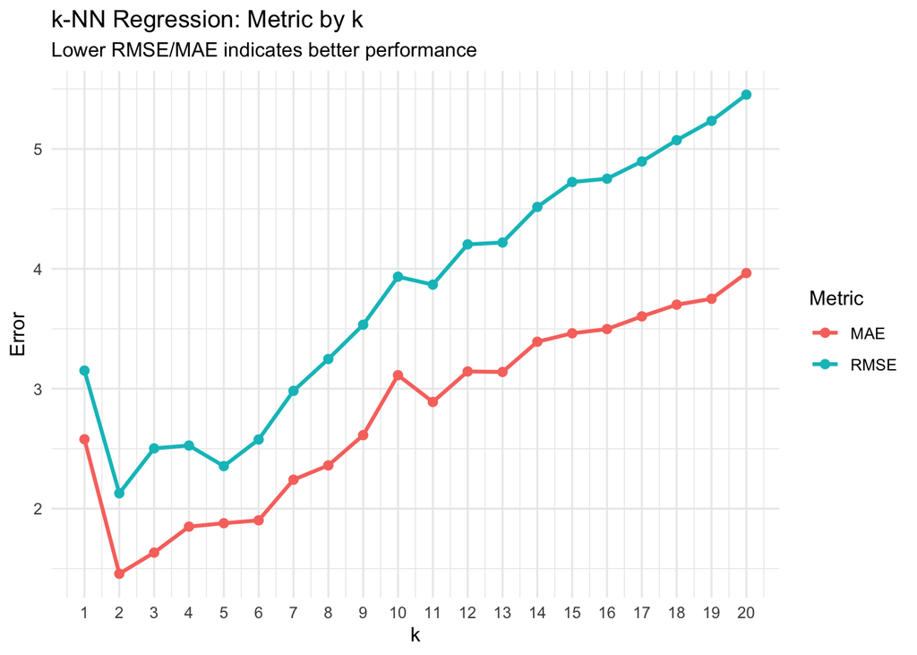

```r
k_values_reg %>%
  map_dfr(function(k) {
    model <- knn_reg_models[[as.character(k)]]
    pred  <- predict(model, newdata = mt_test)

    tibble(
      k    = k,
      RMSE = RMSE(pred, mt_test$mpg),
      MAE  = MAE(pred, mt_test$mpg)
    )
  }) %>%
  pivot_longer(cols = c(RMSE, MAE), names_to = "Metric", values_to = "Value") %>%
  ggplot(aes(x = k, y = Value, color = Metric)) +
  geom_line(linewidth = 1) +
  geom_point(size = 2) +
  scale_x_continuous(breaks = k_values_reg) +
  labs(
    title = "k-NN Regression: Metric by k",
    subtitle = "Lower RMSE/MAE indicates better performance",
    x = "k",
    y = "Error"
  ) +
  theme_minimal()
```

We can also compare our results with a linear regression with the following visualization:

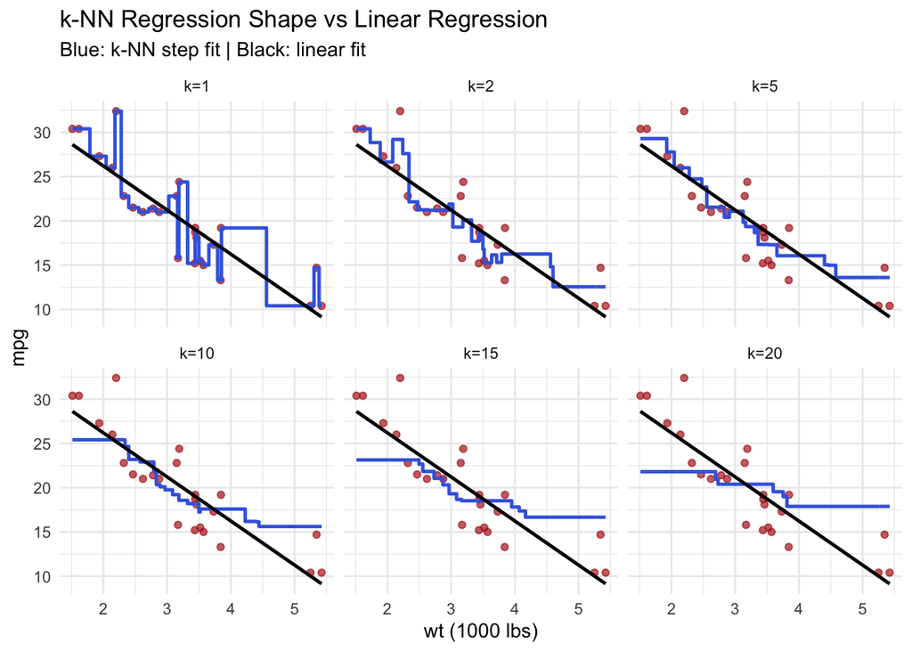

```r
wt_grid <- tibble(wt = seq(min(mt_train$wt), max(mt_train$wt), length.out = 200))
lm_wt <- lm(mpg ~ wt, data = mt_train)

k_keep <- c(1, 2, 5, 10, 15, 20)

plot_data <- tibble()

for (k_val in intersect(k_values_reg, k_keep)) {
  model_k <- knn_reg_models[[as.character(k_val)]]
  plot_data <- bind_rows(
    plot_data,
    tibble(
      wt = wt_grid$wt,
      mpg_knn = predict(model_k, newdata = wt_grid),
      k_label = paste0("k=", k_val)
    )
  )
}

# control facet order, which would be alphabetical if not controlled
plot_data <- plot_data %>%
  mutate(k_label = factor(k_label, levels = paste0("k=", k_keep)))

lm_data <- tibble(
  wt = wt_grid$wt,
  mpg_lm = predict(lm_wt, newdata = wt_grid)
)

ggplot() +
  geom_point(data = mt_train, aes(x = wt, y = mpg), color = "firebrick", alpha = 0.70) +
  geom_step(data = plot_data, aes(x = wt, y = mpg_knn), color = "royalblue", linewidth = 0.9) +
  geom_line(data = lm_data, aes(x = wt, y = mpg_lm), color = "black", linewidth = 0.9) +
  facet_wrap(~ k_label, ncol = 3) +
  labs(
    title = "k-NN Regression Shape vs Linear Regression",
    subtitle = "Blue: k-NN step fit | Black: linear fit",
    x = "wt (1000 lbs)",
    y = "mpg"
  ) +
  theme_minimal()
```

# 4 Real Case Study: Student Failure

Now we apply these methods to a real social-science problem: predicting student failure in mathematics.

## 4.1 Context and Variables

Education is a crucial factor for achieving long-term economic growth.

- Can we explain rates of school failure and dropout?
- Can we predict student performance?

In particular, in Portugal failure in Mathematics and Portuguese is extremely severe. In this case study, we will analyze the factors affecting bad grading in Mathematics in Portuguese schools, and then try to predict their performance based on attributes like demographic, social and school related features.

The dataset we’ll be using contains information on Portuguese secondary school students, with demographic, family, social, and study-related features, plus grades (`G1`, `G2`, `G3`). For this case study we define failure as `G3 < 5` and focus on a compact set of predictors.

Attribute Information:

1. school - student’s school (binary: ‘GP’ - Gabriel Pereira or ‘MS’ - Mousinho da Silveira)
2. sex - student’s sex (binary: ‘F’ - female or ‘M’ - male)
3. age - student’s age (numeric: from 15 to 22)
4. address - student’s home address type (binary: ‘U’ - urban or ‘R’ - rural)
5. famsize - family size (binary: ‘LE3’ - less or equal to 3 or ‘GT3’ - greater than 3)
6. Pstatus - parent’s cohabitation status (binary: ‘T’ - living together or ‘A’ - apart)
7. Medu - mother’s education (numeric: 0 - none, 1 - primary education (4th grade), 2 5th to 9th grade, 3 secondary education or 4 higher education)
8. Fedu - father’s education (numeric: 0 - none, 1 - primary education (4th grade), 2 5th to 9th grade, 3 secondary education or 4 higher education)
9. Mjob - mother’s job (nominal: ‘teacher’, ‘health’ care related, civil ‘services’ (e.g. administrative or police), ‘at_home’ or ‘other’)
10. Fjob - father’s job (nominal: ‘teacher’, ‘health’ care related, civil ‘services’ (e.g. administrative or police), ‘at_home’ or ‘other’)
11. reason - reason to choose this school (nominal: close to ‘home’, school ‘reputation’, ‘course’ preference or ‘other’)
12. guardian - student’s guardian (nominal: ‘mother’, ‘father’ or ‘other’)
13. traveltime - home to school travel time (numeric: 1 - <15 min., 2 - 15 to 30 min., 3 - 30 min. to 1 hour, or 4 - >1 hour)
14. studytime - weekly study time (numeric: 1 - <2 hours, 2 - 2 to 5 hours, 3 - 5 to 10 hours, or 4 - >10 hours)
15. failures - number of past class failures (numeric: n if 1<=n<3, else 4)
16. schoolsup - extra educational support (binary: yes or no)
17. famsup - family educational support (binary: yes or no)
18. paid - extra paid classes within the course subject (Math or Portuguese) (binary: yes or no)
19. activities - extra-curricular activities (binary: yes or no)
20. nursery - attended nursery school (binary: yes or no)
21. higher - wants to take higher education (binary: yes or no)
22. internet - Internet access at home (binary: yes or no)
23. romantic - with a romantic relationship (binary: yes or no)
24. famrel - quality of family relationships (numeric: from 1 - very bad to 5 - excellent)
25. freetime - free time after school (numeric: from 1 - very low to 5 - very high)
26. goout - going out with friends (numeric: from 1 - very low to 5 - very high)
27. Dalc - workday alcohol consumption (numeric: from 1 - very low to 5 - very high)
28. Walc - weekend alcohol consumption (numeric: from 1 - very low to 5 - very high)
29. health - current health status (numeric: from 1 - very bad to 5 - very good)
30. absences - number of school absences (numeric: from 0 to 93)
31. Grades are related with the course subject, Math or Portuguese:
32. G1 - first period grade (numeric: from 0 to 20)
33. G2 - second period grade (numeric: from 0 to 20)
34. G3 - final grade (numeric: from 0 to 20, output target)

```r
math_raw <- read.csv2("student-mat.csv", stringsAsFactors = TRUE)

dim(math_raw)
```

```
## [1] 395  33
```

```r
glimpse(math_raw)
```

```
## Rows: 395
## Columns: 33
## $ school     <fct> GP, GP, GP, GP, GP, GP, GP, GP, GP, GP, GP, GP, GP, GP, GP,…
## $ sex        <fct> F, F, F, F, F, M, M, F, M, M, F, F, M, M, M, F, F, F, M, M,…
## $ age        <int> 18, 17, 15, 15, 16, 16, 16, 17, 15, 15, 15, 15, 15, 15, 15,…
## $ address    <fct> U, U, U, U, U, U, U, U, U, U, U, U, U, U, U, U, U, U, U, U,…
## $ famsize    <fct> GT3, GT3, LE3, GT3, GT3, LE3, LE3, GT3, LE3, GT3, GT3, GT3,…
## $ Pstatus    <fct> A, T, T, T, T, T, T, A, A, T, T, T, T, T, A, T, T, T, T, T,…
## $ Medu       <int> 4, 1, 1, 4, 3, 4, 2, 4, 3, 3, 4, 2, 4, 4, 2, 4, 4, 3, 3, 4,…
## $ Fedu       <int> 4, 1, 1, 2, 3, 3, 2, 4, 2, 4, 4, 1, 4, 3, 2, 4, 4, 3, 2, 3,…
## $ Mjob       <fct> at_home, at_home, at_home, health, other, services, other, …
## $ Fjob       <fct> teacher, other, other, services, other, other, other, teach…
## $ reason     <fct> course, course, other, home, home, reputation, home, home, …
## $ guardian   <fct> mother, father, mother, mother, father, mother, mother, mot…
## $ traveltime <int> 2, 1, 1, 1, 1, 1, 1, 2, 1, 1, 1, 3, 1, 2, 1, 1, 1, 3, 1, 1,…
```

[output cut: 20 more lines]

```r
summary(math_raw$G3)
```

```
##    Min. 1st Qu.  Median    Mean 3rd Qu.    Max.
##    0.00    8.00   11.00   10.42   14.00   20.00
```

We can do a simple data exploration:

```r
# Missingness and duplicates
cat("NAs in raw data:", sum(is.na(math_raw)), "\n")
```

```
## NAs in raw data: 0
```

```r
cat("Duplicated rows in raw data:", sum(duplicated(math_raw)), "\n")
```

```
## Duplicated rows in raw data: 0
```

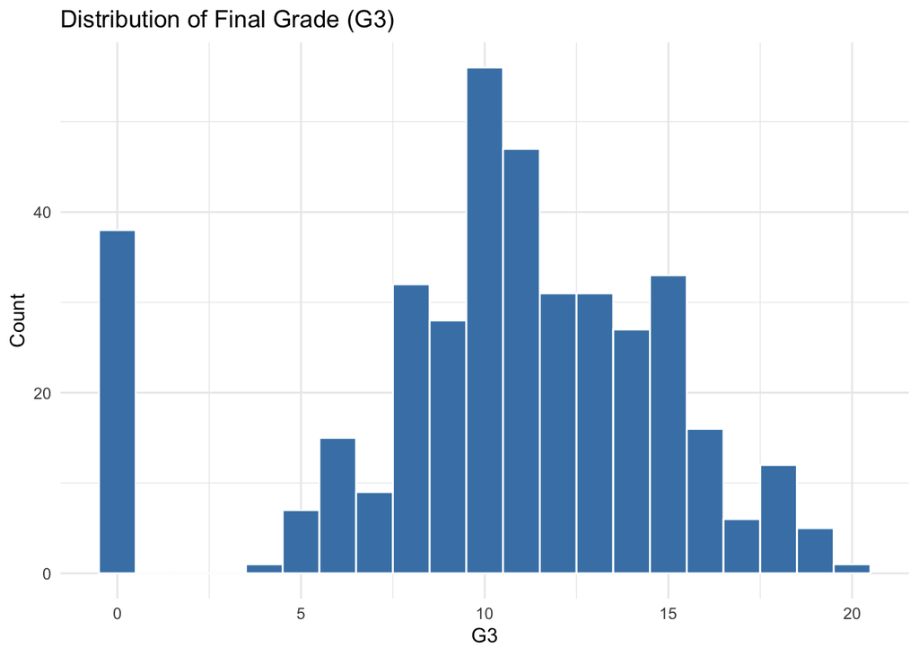

```r
# Distribution of final grade
math_raw %>%
  ggplot(aes(x = G3)) +
  geom_histogram(binwidth = 1, fill = "steelblue", color = "white") +
  labs(title = "Distribution of Final Grade (G3)", x = "G3", y = "Count") +
  theme_minimal()
```

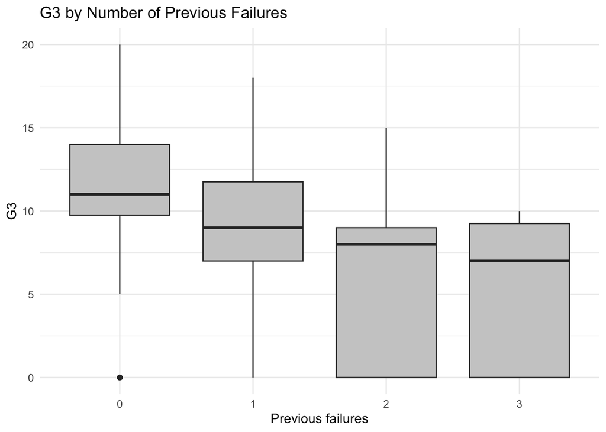

```r
# How failures relate to G3
math_raw %>%
  ggplot(aes(x = as.factor(failures), y = G3)) +
  geom_boxplot(fill = "gray80") +
  labs(title = "G3 by Number of Previous Failures", x = "Previous failures", y = "G3") +
  theme_minimal()
```

Correlations

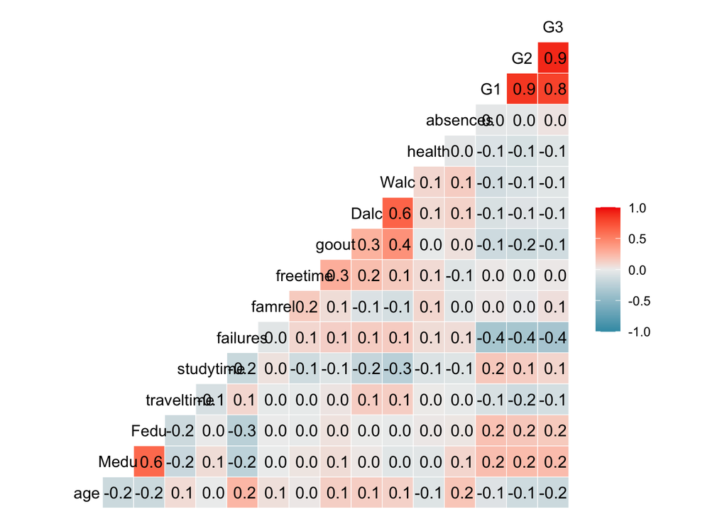

```r
GGally::ggcorr(math_raw, label = T)
```

## 4.2 Data Preprocessing

```r
math <- math_raw %>%
  mutate(Fail = factor(G3 < 5, levels = c(FALSE, TRUE), labels = c("No", "Yes"))) %>%
  dplyr::select(Fail, failures, absences, studytime, Medu, Fedu, Walc, goout, age)

summary(math)
```

```
##   Fail        failures         absences        studytime          Medu
##  No :356   Min.   :0.0000   Min.   : 0.000   Min.   :1.000   Min.   :0.000
##  Yes: 39   1st Qu.:0.0000   1st Qu.: 0.000   1st Qu.:1.000   1st Qu.:2.000
##            Median :0.0000   Median : 4.000   Median :2.000   Median :3.000
##            Mean   :0.3342   Mean   : 5.709   Mean   :2.035   Mean   :2.749
##            3rd Qu.:0.0000   3rd Qu.: 8.000   3rd Qu.:2.000   3rd Qu.:4.000
##            Max.   :3.0000   Max.   :75.000   Max.   :4.000   Max.   :4.000
##       Fedu            Walc           goout            age
##  Min.   :0.000   Min.   :1.000   Min.   :1.000   Min.   :15.0
##  1st Qu.:2.000   1st Qu.:1.000   1st Qu.:2.000   1st Qu.:16.0
##  Median :2.000   Median :2.000   Median :3.000   Median :17.0
##  Mean   :2.522   Mean   :2.291   Mean   :3.109   Mean   :16.7
##  3rd Qu.:3.000   3rd Qu.:3.000   3rd Qu.:4.000   3rd Qu.:18.0
##  Max.   :4.000   Max.   :5.000   Max.   :5.000   Max.   :22.0
```

```r
prop.table(table(math$Fail))
```

```
##
##         No        Yes
## 0.90126582 0.09873418
```

We also do a train/test split

```r
set.seed(2026)
in_train <- createDataPartition(math$Fail, p = 0.8, list = FALSE)
train_df <- math[in_train, ]
test_df <- math[-in_train, ]

cat("Training set:", nrow(train_df), "observations\n")
```

```
## Training set: 317 observations
```

```r
cat("Test set:", nrow(test_df), "observations\n")
```

```
## Test set: 78 observations
```

## 4.3 Fitting the models

Before fitting all the models, we will use a simple variable-selection step with logistic regression (`step`) and then use the selected predictors for LDA, QDA, Naive Bayes and alos for k-NN. However, this cvariable selection could be donde for each of the models by themselves, and they could find different variables to be selected. In this case, for simplicity, we assume that the best variables found by the logistic regression are useful for the rest of the models.

You can start with all the features and remove them one by one, or start with one feature and add features to see if it gets better.

```r
# 1) Logistic regression with variable selection
logit_full <- glm(Fail ~ ., family = binomial(link = "logit"), data = train_df)
logit_model <- step(logit_full, direction = "both", trace = 0)

selected_terms <- attr(terms(logit_model), "term.labels")
if (length(selected_terms) == 0) {
  selected_formula <- Fail ~ failures + absences + studytime + Medu + Fedu + Walc + goout + age
  cat("Stepwise selected no predictors. Falling back to predefined compact feature set.\n")
} else {
  selected_formula <- as.formula(paste("Fail ~", paste(selected_terms, collapse = " + ")))
  cat("Selected predictors:", paste(selected_terms, collapse = ", "), "\n")
}
```

```
## Selected predictors: failures, absences, Walc, age
```

```r
logit_prob <- predict(logit_model, newdata = test_df, type = "response")
logit_pred <- factor(ifelse(logit_prob > 0.5, "Yes", "No"), levels = c("No", "Yes"))

# 2) LDA
lda_model <- lda(selected_formula, data = train_df)
lda_pred <- predict(lda_model, newdata = test_df)$class

# 3) QDA
qda_model <- qda(selected_formula, data = train_df)
qda_pred <- predict(qda_model, newdata = test_df)$class

# 4) Naive Bayes
nb_model <- naiveBayes(selected_formula, data = train_df)
nb_pred <- predict(nb_model, newdata = test_df)
```

With k-NN we do a scree plot to select the optimal `k`

```r
ctrl_knn <- trainControl(method = "cv", number = 5)
knn_grid <- data.frame(k = c(1, 3, 5, 7, 9, 11, 15, 20))

knn_model <- train(
  selected_formula,
  data = train_df,
  method = "knn",
  preProcess = c("center", "scale"),
  trControl = ctrl_knn,
  tuneGrid = knn_grid,
  metric = "Accuracy"
)

knn_pred <- predict(knn_model, newdata = test_df)

knn_tuning <- knn_model$results %>% dplyr::select(k, Accuracy)
knn_tuning
```

```
##    k  Accuracy
## 1  1 0.8992063
## 2  3 0.9148810
## 3  5 0.9086310
## 4  7 0.9180556
## 5  9 0.9118056
## 6 11 0.9149306
## 7 15 0.9118056
## 8 20 0.9055060
```

```r
best_k <- knn_model$bestTune$k
cat("Best k selected by CV:", best_k, "\n")
```

```
## Best k selected by CV: 7
```

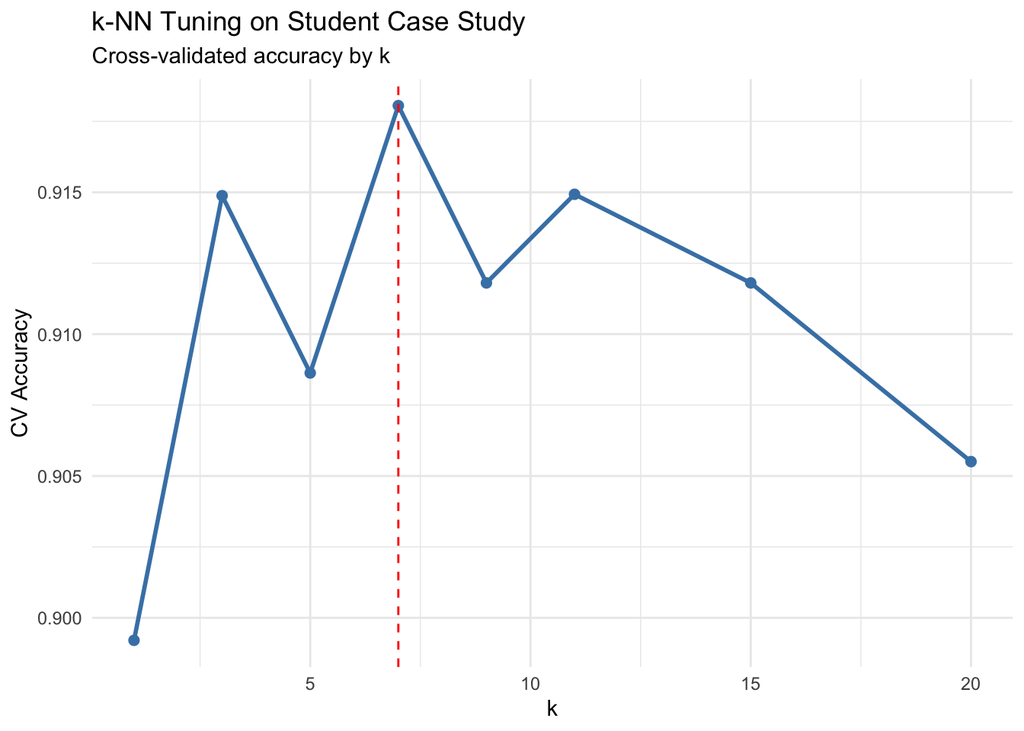

```r
# Scree-like curve
ggplot(knn_tuning, aes(x = k, y = Accuracy)) +
  geom_line(color = "steelblue", linewidth = 1) +
  geom_point(color = "steelblue", size = 2) +
  geom_vline(xintercept = best_k, linetype = "dashed", color = "red") +
  labs(
    title = "k-NN Tuning on Student Case Study",
    subtitle = "Cross-validated accuracy by k",
    x = "k",
    y = "CV Accuracy"
  ) +
  theme_minimal()
```

## 4.4 Results

Confussion matrices:

```r
cm_logit <- confusionMatrix(logit_pred, test_df$Fail, positive = "Yes")
cm_lda <- confusionMatrix(lda_pred, test_df$Fail, positive = "Yes")
cm_qda <- confusionMatrix(qda_pred, test_df$Fail, positive = "Yes")
cm_nb <- confusionMatrix(nb_pred, test_df$Fail, positive = "Yes")
cm_knn <- confusionMatrix(knn_pred, test_df$Fail, positive = "Yes")

cm_logit
```

```
## Confusion Matrix and Statistics
##
##           Reference
## Prediction No Yes
##        No  67   5
##        Yes  4   2
##
##                Accuracy : 0.8846
##                  95% CI : (0.7922, 0.9459)
##     No Information Rate : 0.9103
##     P-Value [Acc > NIR] : 0.8402
##
##                   Kappa : 0.2452
##
##  Mcnemar's Test P-Value : 1.0000
##
##             Sensitivity : 0.28571
##             Specificity : 0.94366
##          Pos Pred Value : 0.33333
##          Neg Pred Value : 0.93056
##              Prevalence : 0.08974
##          Detection Rate : 0.02564
##    Detection Prevalence : 0.07692
##       Balanced Accuracy : 0.61469
##
##        'Positive' Class : Yes
##
```

```r
cm_lda
```

```
## Confusion Matrix and Statistics
##
##           Reference
## Prediction No Yes
##        No  68   6
##        Yes  3   1
##
##                Accuracy : 0.8846
##                  95% CI : (0.7922, 0.9459)
##     No Information Rate : 0.9103
##     P-Value [Acc > NIR] : 0.8402
##
##                   Kappa : 0.1247
##
##  Mcnemar's Test P-Value : 0.5050
##
##             Sensitivity : 0.14286
##             Specificity : 0.95775
##          Pos Pred Value : 0.25000
##          Neg Pred Value : 0.91892
##              Prevalence : 0.08974
##          Detection Rate : 0.01282
##    Detection Prevalence : 0.05128
##       Balanced Accuracy : 0.55030
##
##        'Positive' Class : Yes
##
```

```r
cm_qda
```

```
## Confusion Matrix and Statistics
##
##           Reference
## Prediction No Yes
##        No  66   5
##        Yes  5   2
##
##                Accuracy : 0.8718
##                  95% CI : (0.7768, 0.9368)
##     No Information Rate : 0.9103
##     P-Value [Acc > NIR] : 0.9115
##
##                   Kappa : 0.2153
##
##  Mcnemar's Test P-Value : 1.0000
##
##             Sensitivity : 0.28571
##             Specificity : 0.92958
##          Pos Pred Value : 0.28571
##          Neg Pred Value : 0.92958
##              Prevalence : 0.08974
##          Detection Rate : 0.02564
##    Detection Prevalence : 0.08974
##       Balanced Accuracy : 0.60765
##
##        'Positive' Class : Yes
##
```

```r
cm_nb
```

```
## Confusion Matrix and Statistics
##
##           Reference
## Prediction No Yes
##        No  68   6
##        Yes  3   1
##
##                Accuracy : 0.8846
##                  95% CI : (0.7922, 0.9459)
##     No Information Rate : 0.9103
##     P-Value [Acc > NIR] : 0.8402
##
##                   Kappa : 0.1247
##
##  Mcnemar's Test P-Value : 0.5050
##
##             Sensitivity : 0.14286
##             Specificity : 0.95775
##          Pos Pred Value : 0.25000
##          Neg Pred Value : 0.91892
##              Prevalence : 0.08974
##          Detection Rate : 0.01282
##    Detection Prevalence : 0.05128
##       Balanced Accuracy : 0.55030
##
##        'Positive' Class : Yes
##
```

```r
cm_knn
```

```
## Confusion Matrix and Statistics
##
##           Reference
## Prediction No Yes
##        No  66   5
##        Yes  5   2
##
##                Accuracy : 0.8718
##                  95% CI : (0.7768, 0.9368)
##     No Information Rate : 0.9103
##     P-Value [Acc > NIR] : 0.9115
##
##                   Kappa : 0.2153
##
##  Mcnemar's Test P-Value : 1.0000
##
##             Sensitivity : 0.28571
##             Specificity : 0.92958
##          Pos Pred Value : 0.28571
##          Neg Pred Value : 0.92958
##              Prevalence : 0.08974
##          Detection Rate : 0.02564
##    Detection Prevalence : 0.08974
##       Balanced Accuracy : 0.60765
##
##        'Positive' Class : Yes
##
```

When classes are imbalanced (here, failures are the minority), plain accuracy can be misleading.

Balanced Accuracy gives equal importance to the positive and negative classes:

$$\text{Balanced Accuracy} = \frac{\text{Sensitivity} +
\text{Specificity}}{2}$$

- **Sensitivity**: how many actual failures are correctly detected.
- **Specificity**: how many non-failures are correctly detected.

We can now build a table with several metrics:

```r
extract_metrics <- function(cm_object) {
  tibble(
    Accuracy = as.numeric(cm_object$overall["Accuracy"]),
    Sensitivity = as.numeric(cm_object$byClass["Sensitivity"]),
    Specificity = as.numeric(cm_object$byClass["Specificity"]),
    `Balanced Accuracy` = as.numeric(cm_object$byClass["Balanced Accuracy"])
  )
}

student_results <- bind_rows(
  extract_metrics(cm_logit) %>% mutate(Method = "Logit"),
  extract_metrics(cm_lda) %>% mutate(Method = "LDA"),
  extract_metrics(cm_qda) %>% mutate(Method = "QDA"),
  extract_metrics(cm_nb) %>% mutate(Method = "Naive Bayes"),
  extract_metrics(cm_knn) %>% mutate(Method = paste0("k-NN (k=", best_k, ")"))
) %>%
  dplyr::select(Method, Accuracy, Sensitivity, Specificity, `Balanced Accuracy`)

knitr::kable(student_results, digits = 3)
```

| Method | Accuracy | Sensitivity | Specificity | Balanced Accuracy |
| --- | --- | --- | --- | --- |
| Logit | 0.885 | 0.286 | 0.944 | 0.615 |
| LDA | 0.885 | 0.143 | 0.958 | 0.550 |
| QDA | 0.872 | 0.286 | 0.930 | 0.608 |
| Naive Bayes | 0.885 | 0.143 | 0.958 | 0.550 |
| k-NN (k=7) | 0.872 | 0.286 | 0.930 | 0.608 |

And we can also visualize the results comparing the balanced accuracy (ordered from best o worst) and the accuracy.

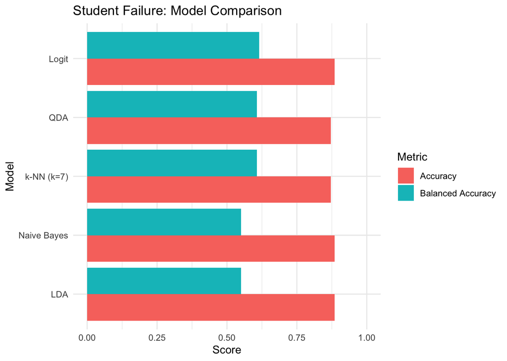

```r
plot_df <- student_results %>%
  dplyr::select(Method, Accuracy, `Balanced Accuracy`) %>%
  pivot_longer(cols = c(Accuracy, `Balanced Accuracy`), names_to = "Metric", values_to = "Value")

ggplot(plot_df, aes(x = reorder(Method, Value), y = Value, fill = Metric)) +
  geom_col(position = "dodge") +
  coord_flip() +
  ylim(0, 1) +
  labs(
    title = "Student Failure: Model Comparison",
    x = "Model",
    y = "Score"
  ) +
  theme_minimal()
```

# 5 Practice Extension

As a practice idea, repeat the same workflow for Portuguese grades (`student-por.csv`) and compare whether the best model is the same.

```r
por_raw <- read.csv2("student-por.csv", stringsAsFactors = TRUE)

por <- por_raw %>%
  mutate(Fail = factor(G3 < 5, levels = c(FALSE, TRUE), labels = c("No", "Yes"))) %>%
  dplyr::select(Fail, failures, absences, studytime, Medu, Fedu, Walc, goout, age)

summary(por)
```

```
##   Fail        failures         absences        studytime          Medu
##  No :633   Min.   :0.0000   Min.   : 0.000   Min.   :1.000   Min.   :0.000
##  Yes: 16   1st Qu.:0.0000   1st Qu.: 0.000   1st Qu.:1.000   1st Qu.:2.000
##            Median :0.0000   Median : 2.000   Median :2.000   Median :2.000
##            Mean   :0.2219   Mean   : 3.659   Mean   :1.931   Mean   :2.515
##            3rd Qu.:0.0000   3rd Qu.: 6.000   3rd Qu.:2.000   3rd Qu.:4.000
##            Max.   :3.0000   Max.   :32.000   Max.   :4.000   Max.   :4.000
##       Fedu            Walc          goout            age
##  Min.   :0.000   Min.   :1.00   Min.   :1.000   Min.   :15.00
##  1st Qu.:1.000   1st Qu.:1.00   1st Qu.:2.000   1st Qu.:16.00
##  Median :2.000   Median :2.00   Median :3.000   Median :17.00
##  Mean   :2.307   Mean   :2.28   Mean   :3.185   Mean   :16.74
##  3rd Qu.:3.000   3rd Qu.:3.00   3rd Qu.:4.000   3rd Qu.:18.00
##  Max.   :4.000   Max.   :5.00   Max.   :5.000   Max.   :22.00
```

```r
prop.table(table(por$Fail))
```

```
##
##         No        Yes
## 0.97534669 0.02465331
```

# 6 Some R packages and advanced Bayesian learning methods

- **Factor-Based Linear Discriminant Analysis:** `HiDimDA`
- **Linear Discriminant Analysis with Stepwise Feature Selection:** `klaR`, `MASS`
- **Penalized Discriminant Analysis:** `mda`, `penalizedLDA`, `klaR`, `rlda`, `sda`, `sparsediscrim`
- **Sparse Linear Discriminant Analysis:** `sparseLDA`, `sparsediscrim`
- **Naive Bayes:** `naivebayes`, `klaR`